# It's Not You, It's The Algorithm

## Tinder Has Trust Issues, Bumble Has a Spending Problem, and Hinge Is Just Trying Its Best

The trust and safety chart on the left and the monetisation chart on the right tell two very different stories about how each app failed its users and whether it noticed.

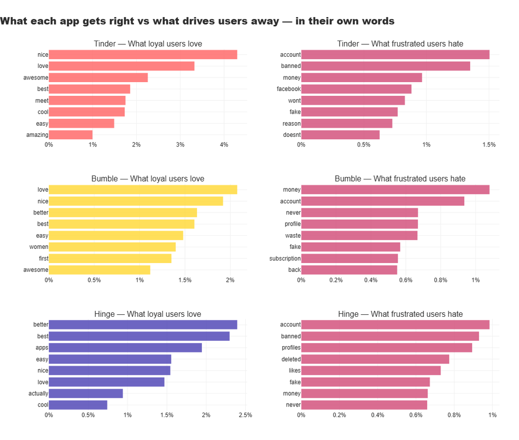

```
Chart 3 saved.
```

```python
from collections import Counter

# Filter to 5-star and 1-star reviews per app
# These are the most signal-rich — love vs hate

stop_words = set(stopwords.words('english'))
custom_stops = {
    'app', 'tinder', 'bumble', 'hinge', 'dating', 'like',
    'good', 'great', 'really', 'would', 'get', 'one',
    'use', 'used', 'using', 'time', 'people', 'make',
    'want', 'need', 'much', 'even', 'also', 'ive',
    'dont', 'cant', 'its', 'im', 'just', 'got', 'will',
    'date', 'dates', 'match', 'matches', 'matched',
    'well', 'way', 'lot', 'many', 'every', 'new',
    'have', 'this', 'that', 'with', 'from', 'they',
    'been', 'more', 'some', 'when', 'your', 'their',
    'said', 'than', 'then', 'them', 'were', 'about'
}
stop_words.update(custom_stops)

def get_top_words(texts, n=30):
    words = []
    for text in texts:
        if pd.isna(text):
            continue
        tokens = str(text).lower().split()
        tokens = [t for t in tokens
                  if t.isalpha()
                  and t not in stop_words
                  and len(t) > 3]
        words.extend(tokens)
    counter = Counter(words)
    total = sum(counter.values())
    return {w: c/total*100 for w, c in counter.most_common(n)}

# Get top words for 5-star and 1-star per app
app_colors = {
    'Tinder': '#FF6B6B',
    'Bumble': '#FFD93D',
    'Hinge' : '#534AB7'
}

fig = make_subplots(
    rows=3, cols=2,
    subplot_titles=[
        'Tinder — What loyal users love',
        'Tinder — What frustrated users hate',
        'Bumble — What loyal users love',
        'Bumble — What frustrated users hate',
        'Hinge — What loyal users love',
        'Hinge — What frustrated users hate',
    ],
    horizontal_spacing=0.12,
    vertical_spacing=0.12
)

row_map = {'Tinder': 1, 'Bumble': 2, 'Hinge': 3}

for app in ['Tinder', 'Bumble', 'Hinge']:
    row = row_map[app]
    color = app_colors[app]

    # 5-star reviews
    positive_texts = df_reviews[
        (df_reviews['App'] == app) &
        (df_reviews['Rating'] == 5)
    ]['review_clean']

    # 1-star reviews
    negative_texts = df_reviews[
        (df_reviews['App'] == app) &
        (df_reviews['Rating'] == 1)
    ]['review_clean']

    pos_words = get_top_words(positive_texts, n=30)
    neg_words = get_top_words(negative_texts, n=30)

    # Find words that appear MORE in positive than negative
    pos_unique = {w: v for w, v in pos_words.items()
                  if v > neg_words.get(w, 0) * 1.5}
    # Find words that appear MORE in negative than positive
    neg_unique = {w: v for w, v in neg_words.items()
                  if v > pos_words.get(w, 0) * 1.5}

    # Top 8 each
    top_pos = sorted(pos_unique.items(),
                     key=lambda x: x[1], reverse=True)[:8]
    top_neg = sorted(neg_unique.items(),
                     key=lambda x: x[1], reverse=True)[:8]

    # Positive chart
    if top_pos:
        words_p = [w for w, c in top_pos]
        vals_p = [c for w, c in top_pos]
        fig.add_trace(go.Bar(
            x=vals_p,
            y=words_p,
            orientation='h',
            marker=dict(color=color, opacity=0.85,
                       line=dict(width=0)),
            hovertemplate=(
                f"<b>{app} — Positive</b><br>"
                "Word: %{y}<br>"
                "Frequency: %{x:.3f}%<extra></extra>"
            ),
            showlegend=False
        ), row=row, col=1)

    # Negative chart
    if top_neg:
        words_n = [w for w, c in top_neg]
        vals_n = [c for w, c in top_neg]
        fig.add_trace(go.Bar(
            x=vals_n,
            y=words_n,
            orientation='h',
            marker=dict(color='#D4537E', opacity=0.85,
                       line=dict(width=0)),
            hovertemplate=(
                f"<b>{app} — Negative</b><br>"
                "Word: %{y}<br>"
                "Frequency: %{x:.3f}%<extra></extra>"
            ),
            showlegend=False
        ), row=row, col=2)

fig.update_layout(
    title=dict(
        text='What each app gets right vs what drives users away — in their own words',
        font=dict(size=20, color='#2d2d2d', family='Arial Black'),
        x=0, pad=dict(b=20)
    ),
    plot_bgcolor='white',
    paper_bgcolor='white',
    height=900,
    margin=dict(l=100, r=40, t=100, b=60),
    font=dict(family='Arial', color='#2d2d2d')
)

fig.update_xaxes(gridcolor='#f0f0f0', ticksuffix='%')
fig.update_yaxes(gridcolor='#f0f0f0', autorange='reversed')

fig.write_html('charts/chart3_loyalty_signal.html')
fig.write_image('charts/chart3_loyalty_signal.png',
                width=1200, height=900, scale=2)

fig.show()
print("Chart 3 saved.")
```

## Different Apps, Different Dreams, Same Terrible Ex-Boyfriend Energy

The positive words tell you exactly what each app sold and whether anyone bought it. Tinder users say "nice" and "awesome" this is the language of genuinely lowered expectations being genuinely met. Bumble users say "women" and "first" they came for the feminist angle and the feminist angle showed up. Hinge users say "better" and "best" which is less a compliment and more a verdict on the competition, but Hinge will take it.

Then the negative column happens. And suddenly all three apps are the same app. Account banned. Fake profile. Money gone. Never working. The branding dissolves completely. Turns out "designed to be deleted" and "make the first move" and "swipe right" are very different promises attached to exactly the same product failure modes.

Three apps spent years carefully crafting three completely distinct personalities. One is the original. One is the feminist one. One is the emotionally intelligent one that definitely went to therapy. And all three of them, with remarkable consistency, found ways to ban real users, miss fake ones, and handle money in a way that inspired creative writing. The differentiation was real. The chaos was shared equally.

```python
from sklearn.preprocessing import LabelEncoder

# === FEATURE SELECTION ===
cluster_features = df_profiles[[
    'age',
    'essay0_length',
    'essays_filled',
    'essay0_vader',
    'drinks',
    'education_clean'
]].copy()

# === ENCODE CATEGORICALS ===
le_drinks = LabelEncoder()
le_edu = LabelEncoder()

cluster_features['drinks_encoded'] = le_drinks.fit_transform(
    cluster_features['drinks'].fillna('not specified'))
cluster_features['edu_encoded'] = le_edu.fit_transform(
    cluster_features['education_clean'].fillna('Unknown'))

cluster_features = cluster_features.drop(
    columns=['drinks', 'education_clean'])

# === FILL REMAINING NULLS ===
cluster_features = cluster_features.fillna(
    cluster_features.median())

# === SCALE ===
scaler = StandardScaler()
scaled = scaler.fit_transform(cluster_features)

# === K-MEANS ===
kmeans = KMeans(n_clusters=5, random_state=42, n_init=10)
df_profiles['cluster'] = kmeans.fit_predict(scaled)

# === ANALYSE CLUSTERS ===
cluster_summary = df_profiles.groupby('cluster').agg(
    count           = ('age', 'count'),
    avg_age         = ('age', 'mean'),
    avg_essay_len   = ('essay0_length', 'mean'),
    avg_essays_filled = ('essays_filled', 'mean'),
    avg_vader       = ('essay0_vader', 'mean'),
    top_education   = ('education_clean', lambda x: x.mode()[0]),
    top_drinks      = ('drinks', lambda x: x.mode()[0] if x.notna().any() else 'unknown')
).round(2)

print(cluster_summary)
```

```
         count  avg_age  avg_essay_len  avg_essays_filled  avg_vader  \
cluster
0         7775    46.99       1,325.35               8.88       0.95
1        20106    28.54         545.95               8.83       0.88
2        10586    30.60         107.53               5.19      -0.06
3         8000    31.79         541.78               8.63       0.79
4        11093    31.40         561.75               8.58       0.86

              top_education top_drinks
cluster
0        College/University   socially
1        College/University   socially
2        College/University   socially
3        College/University      often
4                   Masters   socially
```

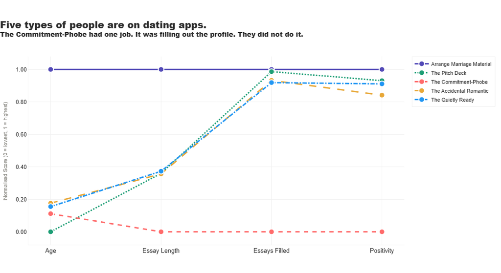

```
Chart 4 saved.
```

```python
persona_names = {
    0: 'Arrange Marriage Material',
    1: 'The Pitch Deck',
    2: 'The Commitment-Phobe',
    3: 'The Accidental Romantic',
    4: 'The Quietly Ready'
}
persona_colors = {
    0: '#534AB7',  # Purple — Arrange Marriage Material
    1: '#1D9E75',  # Teal — The Pitch Deck
    2: '#FF6B6B',  # Red — The Commitment-Phobe
    3: '#E8A838',  # Orange — The Accidental Romantic
    4: '#2196F3'   # Blue — The Quietly Ready
}

persona_dash = {
    0: 'solid',
    1: 'dot',
    2: 'dash',
    3: 'longdash',
    4: 'dashdot'
}

persona_descriptions = {
    0: 'Oldest · Writes the most · Most positive · Already named the dog',
    1: 'Youngest · Moderate essays · Profile optimised · Intentions unclear',
    2: 'Barely tried · 107 words · Flat sentiment · One job. Did not do it.',
    3: 'Came for casual · Stayed for feelings · Currently in denial',
    4: 'Masters educated · Short essays · Done performing · Just waiting'
}

df_profiles['persona'] = df_profiles['cluster'].map(persona_names)

radar_features = ['avg_age', 'avg_essay_len',
                  'avg_essays_filled', 'avg_vader']
radar_labels = ['Age', 'Essay Length',
                'Essays Filled', 'Positivity']

radar_data = cluster_summary[radar_features].copy()
radar_norm = (radar_data - radar_data.min()) / (
    radar_data.max() - radar_data.min())
radar_norm['cluster'] = radar_norm.index
radar_norm['persona'] = radar_norm['cluster'].map(persona_names)
radar_norm['color'] = radar_norm['cluster'].map(persona_colors)

# Raw values for hover
raw_vals = cluster_summary[radar_features].copy()
raw_vals.columns = radar_labels

fig = go.Figure()

for _, row in radar_norm.iterrows():
    cid = int(row['cluster'])
    raw = raw_vals.loc[cid]

    hover_lines = [
        f"<b>{row['persona']}</b>",
        f"<i>{persona_descriptions[cid]}</i>",
        "─────────────────",
        f"Age: {raw['Age']:.1f}",
        f"Essay Length: {raw['Essay Length']:.0f} words",
        f"Essays Filled: {raw['Essays Filled']:.1f} / 10",
        f"Positivity: {raw['Positivity']:.3f}"
    ]

    fig.add_trace(go.Scatter(
        x=radar_labels,
        y=[row['avg_age'],
           row['avg_essay_len'],
           row['avg_essays_filled'],
           row['avg_vader']],
        mode='lines+markers',
        name=row['persona'],
        line=dict(
            color=row['color'],
            width=3,
            dash=persona_dash[cid]
        ),
        marker=dict(
            size=12,
            color=row['color'],
            line=dict(color='white', width=2),
            symbol='circle'
        ),
        hovertemplate=(
            "<br>".join(hover_lines) +
            "<extra></extra>"
        )
    ))

fig.update_layout(
    title=dict(
        text='Five types of people are on dating apps.<br>'
             '<sup>The Commitment-Phobe had one job. '
             'It was filling out the profile. '
             'They did not do it.</sup>',
        font=dict(size=20, color='#2d2d2d',
                  family='Arial Black'),
        x=0, pad=dict(b=20)
    ),
    xaxis=dict(
        gridcolor='#f0f0f0',
        tickfont=dict(size=13, family='Arial',
                      color='#2d2d2d'),
        linecolor='#f0f0f0'
    ),
    yaxis=dict(
        gridcolor='#f0f0f0',
        tickformat='.2f',
        title=dict(
            text='Normalised Score (0 = lowest, 1 = highest)',
            font=dict(size=11, color='#888780')
        ),
        linecolor='#f0f0f0'
    ),
    plot_bgcolor='white',
    paper_bgcolor='white',
    height=580,
    margin=dict(l=60, r=40, t=120, b=60),
    font=dict(family='Arial', color='#2d2d2d'),
    legend=dict(
        bordercolor='#f0f0f0',
        borderwidth=1,
        font=dict(size=11),
        itemclick='toggle',
        itemdoubleclick='toggleothers'
    ),
    hoverlabel=dict(
        bgcolor='white',
        bordercolor='#f0f0f0',
        font=dict(size=12, family='Arial',
                  color='#2d2d2d')
    )
)

fig.write_html('charts/chart4_dating_personas.html')
fig.write_image('charts/chart4_dating_personas.png',
                width=1200, height=580, scale=2)
fig.show()
print("Chart 4 saved.")
```